# Part I: Research Question

```python
# Remove feature with highest p-value and repeat until all p-values are <0.05 (5%)
cleaned_predictor_variables = cleaned_predictor_variables.drop('Children_Count', axis=1)
churn_logit_model = sm.OLS(target, cleaned_predictor_variables).fit()
print(churn_logit_model.summary())
```

```
                            OLS Regression Results
==============================================================================
Dep. Variable:                  Churn   R-squared:                       0.471
Model:                            OLS   Adj. R-squared:                  0.470
Method:                 Least Squares   F-statistic:                     522.6
Date:                Fri, 25 Feb 2022   Prob (F-statistic):               0.00
Time:                        07:56:39   Log-Likelihood:                -2826.9
No. Observations:               10000   AIC:                             5690.
Df Residuals:                    9982   BIC:                             5820.
Df Model:                          17
Covariance Type:            nonrobust
===============================================================================================================
                                                  coef    std err          t      P>|t|      [0.025      0.975]
---------------------------------------------------------------------------------------------------------------
Is_Techie                                       0.0775      0.010      7.994      0.000       0.059       0.097
Has_Phone_Service                              -0.0287      0.012     -2.485      0.013      -0.051      -0.006
Has_Multiple_Lines                              0.0736      0.009      8.340      0.000       0.056       0.091
Has_Online_Backup                               0.0267      0.008      3.465      0.001       0.012       0.042
Has_Device_Protection                           0.0209      0.007      3.026      0.002       0.007       0.034
Has_Streaming_TV                                0.1636      0.010     16.256      0.000       0.144       0.183
Has_Streaming_Movies                            0.1902      0.012     16.461      0.000       0.168       0.213
Gender_Male                                     0.0188      0.006      2.921      0.003       0.006       0.031
Contract_Term_Month-to-month                    0.1617      0.007     22.453      0.000       0.148       0.176
Contract_Term_One year                         -0.0722      0.008     -8.783      0.000      -0.088      -0.056
Contract_Term_Two Year                         -0.0774      0.008     -9.571      0.000      -0.093      -0.062
Internet_Service_Type_DSL                       0.1215      0.007     17.141      0.000       0.108       0.135
Payment_Method_Type_Credit Card (automatic)     0.0137      0.010      1.402      0.161      -0.005       0.033
Payment_Method_Type_Electronic Check            0.0382      0.009      4.359      0.000       0.021       0.055
Payment_Method_Type_Mailed Check                0.0150      0.010      1.572      0.116      -0.004       0.034
Tenure                                         -0.0046      0.000    -15.703      0.000      -0.005      -0.004
Avg_Monthly_Charge                              0.0013      0.000      7.344      0.000       0.001       0.002
Avg_Bandwidth_GB_Usage_Per_Year             -4.684e-05   3.59e-06    -13.050      0.000   -5.39e-05   -3.98e-05
intercept                                       0.0122      0.018      0.666      0.505      -0.024       0.048
==============================================================================
Omnibus:                      981.077   Durbin-Watson:                   1.965
Prob(Omnibus):                  0.000   Jarque-Bera (JB):              358.472
Skew:                           0.223   Prob(JB):                     1.44e-78
Kurtosis:                       2.187   Cond. No.                     5.84e+18
==============================================================================

Notes:
[1] Standard Errors assume that the covariance matrix of the errors is correctly specified.
[2] The smallest eigenvalue is 4.66e-27. This might indicate that there are
strong multicollinearity problems or that the design matrix is singular.
```

```python
# Remove feature with highest p-value and repeat until all p-values are <0.05 (5%)
cleaned_predictor_variables = cleaned_predictor_variables.drop('Payment_Method_Type_Credit Card (automatic)', axis=1)
churn_logit_model = sm.OLS(target, cleaned_predictor_variables).fit()
print(churn_logit_model.summary())
```

```
                            OLS Regression Results
==============================================================================
Dep. Variable:                  Churn   R-squared:                       0.471
Model:                            OLS   Adj. R-squared:                  0.470
Method:                 Least Squares   F-statistic:                     555.1
Date:                Fri, 25 Feb 2022   Prob (F-statistic):               0.00
Time:                        07:56:39   Log-Likelihood:                -2827.9
No. Observations:               10000   AIC:                             5690.
Df Residuals:                    9983   BIC:                             5812.
Df Model:                          16
Covariance Type:            nonrobust
========================================================================================================
                                           coef    std err          t      P>|t|      [0.025      0.975]
--------------------------------------------------------------------------------------------------------
Is_Techie                                0.0775      0.010      7.995      0.000       0.059       0.097
Has_Phone_Service                       -0.0288      0.012     -2.490      0.013      -0.051      -0.006
Has_Multiple_Lines                       0.0735      0.009      8.330      0.000       0.056       0.091
Has_Online_Backup                        0.0267      0.008      3.469      0.001       0.012       0.042
Has_Device_Protection                    0.0208      0.007      3.015      0.003       0.007       0.034
Has_Streaming_TV                         0.1637      0.010     16.258      0.000       0.144       0.183
Has_Streaming_Movies                     0.1904      0.012     16.479      0.000       0.168       0.213
Gender_Male                              0.0189      0.006      2.931      0.003       0.006       0.032
Contract_Term_Month-to-month             0.1634      0.007     23.016      0.000       0.150       0.177
Contract_Term_One year                  -0.0706      0.008     -8.671      0.000      -0.087      -0.055
Contract_Term_Two Year                  -0.0757      0.008     -9.467      0.000      -0.091      -0.060
Internet_Service_Type_DSL                0.1213      0.007     17.117      0.000       0.107       0.135
Payment_Method_Type_Electronic Check     0.0316      0.007      4.280      0.000       0.017       0.046
Payment_Method_Type_Mailed Check         0.0084      0.008      1.011      0.312      -0.008       0.025
Tenure                                  -0.0046      0.000    -15.696      0.000      -0.005      -0.004
Avg_Monthly_Charge                       0.0013      0.000      7.339      0.000       0.001       0.002
Avg_Bandwidth_GB_Usage_Per_Year      -4.684e-05   3.59e-06    -13.047      0.000   -5.39e-05   -3.98e-05
intercept                                0.0172      0.018      0.960      0.337      -0.018       0.052
==============================================================================
Omnibus:                      978.816   Durbin-Watson:                   1.966
Prob(Omnibus):                  0.000   Jarque-Bera (JB):              358.440
Skew:                           0.224   Prob(JB):                     1.46e-78
Kurtosis:                       2.188   Cond. No.                     7.07e+18
==============================================================================

Notes:
[1] Standard Errors assume that the covariance matrix of the errors is correctly specified.
[2] The smallest eigenvalue is 3.18e-27. This might indicate that there are
strong multicollinearity problems or that the design matrix is singular.
```

```python
# Remove feature with highest p-value and repeat until all p-values are <0.05 (5%)
cleaned_predictor_variables = cleaned_predictor_variables.drop('Payment_Method_Type_Mailed Check', axis=1)
churn_logit_model = sm.OLS(target, cleaned_predictor_variables).fit()
print(churn_logit_model.summary())
```

```
                            OLS Regression Results
==============================================================================
Dep. Variable:                  Churn   R-squared:                       0.471
Model:                            OLS   Adj. R-squared:                  0.470
Method:                 Least Squares   F-statistic:                     592.0
Date:                Fri, 25 Feb 2022   Prob (F-statistic):               0.00
Time:                        07:56:39   Log-Likelihood:                -2828.4
No. Observations:               10000   AIC:                             5689.
Df Residuals:                    9984   BIC:                             5804.
Df Model:                          15
Covariance Type:            nonrobust
========================================================================================================
                                           coef    std err          t      P>|t|      [0.025      0.975]
--------------------------------------------------------------------------------------------------------
Is_Techie                                0.0775      0.010      7.991      0.000       0.058       0.097
Has_Phone_Service                       -0.0288      0.012     -2.493      0.013      -0.051      -0.006
Has_Multiple_Lines                       0.0735      0.009      8.330      0.000       0.056       0.091
Has_Online_Backup                        0.0267      0.008      3.470      0.001       0.012       0.042
Has_Device_Protection                    0.0208      0.007      3.013      0.003       0.007       0.034
Has_Streaming_TV                         0.1637      0.010     16.259      0.000       0.144       0.183
Has_Streaming_Movies                     0.1905      0.012     16.482      0.000       0.168       0.213
Gender_Male                              0.0188      0.006      2.913      0.004       0.006       0.031
Contract_Term_Month-to-month             0.1642      0.007     23.257      0.000       0.150       0.178
Contract_Term_One year                  -0.0698      0.008     -8.613      0.000      -0.086      -0.054
Contract_Term_Two Year                  -0.0749      0.008     -9.414      0.000      -0.091      -0.059
Internet_Service_Type_DSL                0.1213      0.007     17.122      0.000       0.107       0.135
Payment_Method_Type_Electronic Check     0.0286      0.007      4.220      0.000       0.015       0.042
Tenure                                  -0.0046      0.000    -15.697      0.000      -0.005      -0.004
Avg_Monthly_Charge                       0.0013      0.000      7.335      0.000       0.001       0.002
Avg_Bandwidth_GB_Usage_Per_Year      -4.683e-05   3.59e-06    -13.044      0.000   -5.39e-05   -3.98e-05
intercept                                0.0195      0.018      1.099      0.272      -0.015       0.054
==============================================================================
Omnibus:                      979.018   Durbin-Watson:                   1.966
Prob(Omnibus):                  0.000   Jarque-Bera (JB):              358.065
Skew:                           0.223   Prob(JB):                     1.77e-78
Kurtosis:                       2.188   Cond. No.                     8.97e+17
==============================================================================

Notes:
[1] Standard Errors assume that the covariance matrix of the errors is correctly specified.
[2] The smallest eigenvalue is 1.97e-25. This might indicate that there are
strong multicollinearity problems or that the design matrix is singular.
```

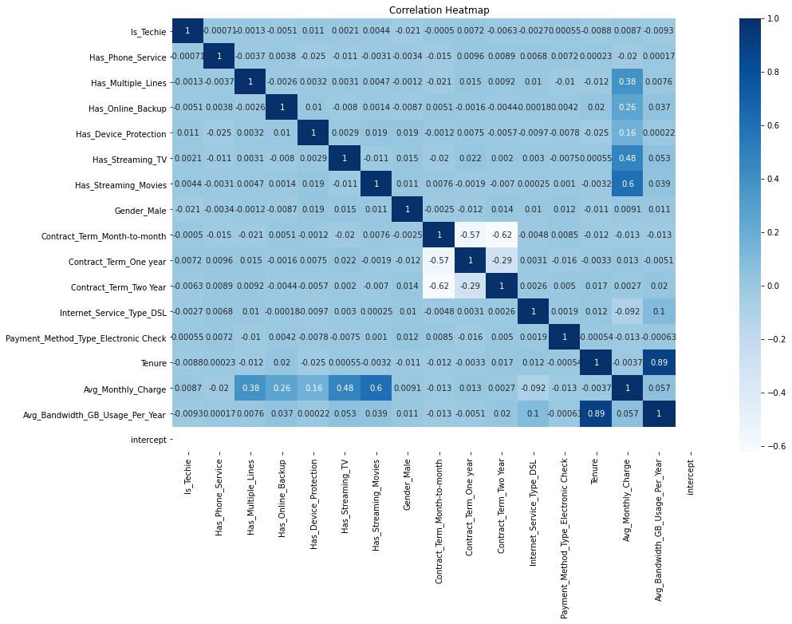

```python
# look for highly correlated variables
fig = plt.figure(figsize=(15,10))
sns.heatmap(cleaned_predictor_variables.corr(method='pearson'), annot = True, cmap="Blues")
plt.title("Correlation Heatmap")
```

```python
# Reocmmended: drop Tenure, Avg_Bandwidth_Usage_Per_Year, Avg_Monthly_Charge which may be causing multicollinearity
# cleaned_predictor_variables = cleaned_predictor_variables.drop(['Tenure', 'Avg_Bandwidth_GB_Usage_Per_Year', 'Avg_Monthly_Charge', 'Contract_Term_Month-to-month'], axis=1)
# churn_logit_model = sm.OLS(target, cleaned_predictor_variables).fit()
# print(churn_logit_model.summary())

# Need to keep conitnuous variables to meet the requirements of the project not because they are the best feature to keep
```

## D.3 Provide a reduced multiple regression model that includes both categorical and continuous variables.

Note: The output should include a screenshot of each model.

```python
reduced_churn_model = sm.OLS(target, cleaned_predictor_variables).fit()
print(reduced_churn_model.summary())
```

```
                            OLS Regression Results
==============================================================================
Dep. Variable:                  Churn   R-squared:                       0.471
Model:                            OLS   Adj. R-squared:                  0.470
Method:                 Least Squares   F-statistic:                     592.0
Date:                Fri, 25 Feb 2022   Prob (F-statistic):               0.00
Time:                        08:04:10   Log-Likelihood:                -2828.4
No. Observations:               10000   AIC:                             5689.
Df Residuals:                    9984   BIC:                             5804.
Df Model:                          15
Covariance Type:            nonrobust
========================================================================================================
                                           coef    std err          t      P>|t|      [0.025      0.975]
--------------------------------------------------------------------------------------------------------
Is_Techie                                0.0775      0.010      7.991      0.000       0.058       0.097
Has_Phone_Service                       -0.0288      0.012     -2.493      0.013      -0.051      -0.006
Has_Multiple_Lines                       0.0735      0.009      8.330      0.000       0.056       0.091
Has_Online_Backup                        0.0267      0.008      3.470      0.001       0.012       0.042
Has_Device_Protection                    0.0208      0.007      3.013      0.003       0.007       0.034
Has_Streaming_TV                         0.1637      0.010     16.259      0.000       0.144       0.183
Has_Streaming_Movies                     0.1905      0.012     16.482      0.000       0.168       0.213
Gender_Male                              0.0188      0.006      2.913      0.004       0.006       0.031
Contract_Term_Month-to-month             0.1642      0.007     23.257      0.000       0.150       0.178
Contract_Term_One year                  -0.0698      0.008     -8.613      0.000      -0.086      -0.054
Contract_Term_Two Year                  -0.0749      0.008     -9.414      0.000      -0.091      -0.059
Internet_Service_Type_DSL                0.1213      0.007     17.122      0.000       0.107       0.135
Payment_Method_Type_Electronic Check     0.0286      0.007      4.220      0.000       0.015       0.042
Tenure                                  -0.0046      0.000    -15.697      0.000      -0.005      -0.004
Avg_Monthly_Charge                       0.0013      0.000      7.335      0.000       0.001       0.002
Avg_Bandwidth_GB_Usage_Per_Year      -4.683e-05   3.59e-06    -13.044      0.000   -5.39e-05   -3.98e-05
intercept                                0.0195      0.018      1.099      0.272      -0.015       0.054
==============================================================================
Omnibus:                      979.018   Durbin-Watson:                   1.966
Prob(Omnibus):                  0.000   Jarque-Bera (JB):              358.065
Skew:                           0.223   Prob(JB):                     1.77e-78
Kurtosis:                       2.188   Cond. No.                     8.97e+17
==============================================================================

Notes:
[1] Standard Errors assume that the covariance matrix of the errors is correctly specified.
[2] The smallest eigenvalue is 1.97e-25. This might indicate that there are
strong multicollinearity problems or that the design matrix is singular.
```

## E. Analyze the data set using your reduced multiple regression model by doing the following:

1. Explain your data analysis process by comparing the initial and reduced multiple regression models, including the following elements:

• the logic of the variable selection technique

- univariate and bivariate visualizations and analyzation

• the model evaluation metric

- listed above

• a residual plot

- https://www.statology.org/residual-plot-python/
1. Provide the output and any calculations of the analysis you performed, including the model’s residual error.
   - See the reduced model's std err column in the output.

Note: The output should include the predictions from the refined model you used to perform the analysis.

1. Provide the code used to support the implementation of the multiple regression models.